# Energy Capacity and Generation Gap in Indonesia

### Findings & 2024 Prediction

```python
find_2024 = combined_df[combined_df['Year'] ==2021].reset_index().drop(['index', 'Year','energy_generated'], axis=1)
predicted_2024_ecap = ridge_cv.predict(find_2024.drop(['Province', 'energy_capacity'],axis=1))
find_2024['2024 Predicted Energy Capacity (MW)'] = predicted_2024_ecap
rd_predicted = find_2024[['Province', '2024 Predicted Energy Capacity (MW)']]

max_caps = []

# we need to change capacity (MW) to maximum generation (GWh) by multiplying it by total hours in a year and dividing by 1000
for i in range(rd_predicted.shape[0]):
    max_caps.append(rd_predicted['2024 Predicted Energy Capacity (MW)'][i] * 8784 / 1000)

rd_predicted['2024 Predicted Maximum Generation (GWh)'] = max_caps

rd_predicted
```

|  | Province | 2024 Predicted Energy Capacity (MW) | 2024 Predicted Maximum Generation (GWh) |
| --- | --- | --- | --- |
| 0 | ACEH | 1094.151988 | 9611.031064 |
| 1 | SUMATERA UTARA | 3800.150780 | 33380.524452 |
| 2 | SUMATERA BARAT | 1146.867921 | 10074.087820 |
| 3 | RIAU | 2514.031170 | 22083.249795 |
| 4 | JAMBI | 731.575714 | 6426.161072 |
| 5 | SUMATERA SELATAN | 1476.029492 | 12965.443055 |
| 6 | BENGKULU | 1370.144276 | 12035.347322 |
| 7 | LAMPUNG | 965.944050 | 8484.852535 |
| 8 | KEP. BANGKA BELITUNG | 372.676798 | 3273.592991 |
| 9 | KEP. RIAU | 1655.485479 | 14541.784445 |
| 10 | DKI JAKARTA | 7264.801103 | 63814.012890 |
| 11 | JAWA BARAT | 11979.185889 | 105225.168845 |
| 12 | JAWA TENGAH | 4806.521310 | 42220.483190 |
| 13 | DI YOGYAKARTA | 5772.825850 | 50708.502270 |
| 14 | JAWA TIMUR | 5708.627436 | 50144.583399 |
| 15 | BANTEN | 7547.854035 | 66300.349839 |
| 16 | BALI | 1102.823127 | 9687.198352 |
| 17 | NUSA TENGGARA BARAT | 704.879920 | 6191.665220 |
| 18 | NUSA TENGGARA TIMUR | 811.371687 | 7127.088902 |
| 19 | KALIMANTAN BARAT | 1000.253355 | 8786.225468 |
| 20 | KALIMANTAN TENGAH | 276.425979 | 2428.125800 |
| 21 | KALIMANTAN SELATAN | 668.211927 | 5869.573571 |
| 22 | KALIMANTAN TIMUR | 1347.855453 | 11839.562297 |
| 23 | KALIMANTAN UTARA | 407.715358 | 3581.371704 |
| 24 | SULAWESI UTARA | 1558.855965 | 13692.990797 |
| 25 | SULAWESI TENGAH | 699.520321 | 6144.586496 |
| 26 | SULAWESI SELATAN | 1448.663995 | 12725.064530 |
| 27 | SULAWESI TENGGARA | 895.218772 | 7863.601696 |
| 28 | GORONTALO | 876.436002 | 7698.613841 |
| 29 | SULAWESI BARAT | 936.151269 | 8223.152750 |
| 30 | MALUKU | 244.700039 | 2149.445147 |
| 31 | MALUKU UTARA | 281.527920 | 2472.941252 |
| 32 | PAPUA BARAT | 141.088235 | 1239.319057 |
| 33 | PAPUA | 1104.548710 | 9702.355869 |
| 34 | INDONESIA | 76812.300825 | 674719.250447 |

## PQ3: Optimal Or Not [Classification]

### Making Multiclass Classification Target Variable

Our overarching question is trying to predict whether or not a province's electricity generation, given its socioeconomic factors, is at a certain amount of efficiency. Indonesia's main source of energy is from coal and fossil fuels. After research, we found that most power plants that use similar sources have an efficiency of around 40%, and those that are very efficient peak out at around 60%. Using this information, we determined our threshold of "not efficient" to be below (33.33)%, or 1/3. For the plants that we thought were "adequate efficiency" were between the values 33% and 60%. Lastly, power plants that were above 60% were our final class. To calculate the plants efficiency, we took the province's energy capacity (Mega Watts or MW) and multiplied it by the number of hours (h) in a year to get their maximum possible of energy in Mega Watt hours, or MWh). Then, we needed to convert the MWh to Gigawatt hours, or GWh, which is the unit that Energy Generation is measured in. Once we translated that over, we divided each energy generation value by its corresponding maximum possible energy generated to get their efficiency.

As mentioned above, we split into three classes based on our thresholds. In terms of how we put that into code, if a province's efficiency was below 1/3, it was class 0. If it was above 1/3 and below 0.6, then it was classified as class 1. If its efficiency was above 0.6, then it was placed in class 2. Class 0 had 104 observations, Class 1 had 100 observations, and Class 2 had 28 observations. For these classes, we inherently made the most efficient class the smallest class. In doing so, it seems like being above the threshold can seem like something "exclusive", thus pushing provinces to strive to reach numbers above this threshold. Another point about the classes is that it was intentional of making the classes having an order of 0, 1, and 2. This is because we want there to be ordering in the classification; the power plants that are more efficient can be considered better than those that are not.

After the target classification variable was created, we added it to our dataframe and did a little more cleaning (dropped NaNs and the Indonesia province, as that row was just the sum or average of all the features in Indonesia). Then, we dropped columns that we didn't want to be features (province name, year, energy capactiy and generation), made the X and y variables, and did our train test split. For the split, we chose to do a 0.2 test size. We didn't want to do any larger than that since we already don't have that much data, but we didn't want to do any smaller as we would be losing data on our training. All things considered, we felt that 0.2 test size was the best middle ground we could do.

### Models: KNN, Decision Trees, Random Forest

In the below cell we prepare X and y (target variable), and split up data into training & testing sets.

```python
egen_df['energy_capacity'] = ecap_df['energy_capacity']

max_caps = []
for i in range(egen_df.shape[0]):
    if egen_df['Year'][i] == 2012 or egen_df['Year'][i] == 2016:
        max_caps.append(egen_df['energy_capacity'][i] * 8784 / 1000)
    else:
        max_caps.append(egen_df['energy_capacity'][i] * 8760 / 1000)

egen_df['maximum_generation'] = max_caps
egen_df_no_na = egen_df.dropna()

energy_efficiency = egen_df_no_na['energy_generated'] / egen_df_no_na['maximum_generation']

def make_target(x):
    if x > 0.6:
        return 2
    elif x > (1/3):
        return 1
    else:
        return 0

target = energy_efficiency.apply(make_target)

egen_df_no_na['Target'] = target
classification_df = egen_df_no_na.copy()
print(classification_df['Target'].value_counts())

## need to drop 'Indonesia' province because that is just the sum of all the provinces, also drop other non-feature columns
df_all = classification_df[classification_df['Province'] != 'INDONESIA']
X = df_all.drop(columns=["Province", "Year", "energy_generated", "energy_capacity", "maximum_generation", 'Target'], axis = 1)
y = df_all["Target"]
X_train, X_test, y_train, y_test = train_test_split(X, y, test_size=0.2, random_state = 9)
```

```
0    104
1    100
2     28
Name: Target, dtype: int64
A value is trying to be set on a copy of a slice from a DataFrame.
Try using .loc[row_indexer,col_indexer] = value instead

See the caveats in the documentation: https://pandas.pydata.org/pandas-docs/stable/user_guide/indexing.html#returning-a-view-versus-a-copy
```

K-Nearest Neighbors

The first classification model we made was K-nearest Neighbors, or KNN. The reason behind picking this is that it is fairly simple model, both in it's implementation and its understanding. Therefore, this can give us a baseline to compare our other models with.

As a general rule of thumb, we wanted k to be around the square root of the total number of observations, which in this case would be 15. However, for this multiclass model, the smallest class only had 28 observations, so 15 would be way too large of a k. To figure out a good value for k, we used 10 fold cross validation to find the best value of k, and found that 3 was also the one it chose. We agreed with this choice because for two main reasons. The first one is the one I just mentioned in having a class that was quite small. Secondly, we don't know exactly how many patterns there are in the data, and because the data is fairly trustworthy in that it was collected by the government, the hope is that there isn't too much noise.

For the majority of this classification section, we decided to do cross validation with 10 folds. Most commonly, the number of folds is usually either 10 or 5, so those were the choices we came down to. The reasoning behind opting for 10 is that our dataset is rather small and has a lot of variance.

- For the first aspect, there are 38 provinces in Indonesia and we only have 7 years of features (from 2011 to 2018, excluding 2016). That leaves us with 266 observations, not to mention that we would end up dropping a few do deal with NaN values.
- For the second part, each row represents a different province, and each province has a lot of variation in their socioeconomic factors. Because of this large variance, the hope is that by increasing the number of folds in the cross validation that this variance will average out across the folds, giving us a better cv accuracy at the end.

```
Best Parameters:  {'n_neighbors': 3}
Best Cross-Validated Score: 0.64
Test Set Accuracy with Best Parameters: 0.62
```

```
<sklearn.metrics._plot.confusion_matrix.ConfusionMatrixDisplay at 0x7f378e82d910>
```

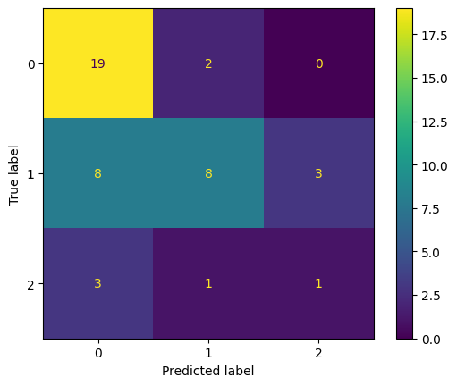

```python
MinMaxScaler = preprocessing.MinMaxScaler()
X_minmax = MinMaxScaler.fit_transform(X)
knn_X_train, knn_X_test, knn_y_train, knn_y_test = train_test_split(X_minmax, y, test_size=0.2, random_state=9)

#### Cross Validation

param_grid_knn = {'n_neighbors': [3, 5, 7, 9, 11]}

# Create a KNN classifier
knn_classifier = KNeighborsClassifier()

# Use GridSearchCV for cross-validation and parameter tuning
knn_grid_search = GridSearchCV(knn_classifier, param_grid_knn, cv=10, scoring='accuracy')
knn_grid_search.fit(knn_X_train, knn_y_train)

# Print the best parameters and corresponding mean cross-validated score
print("Best Parameters: ", knn_grid_search.best_params_)
print("Best Cross-Validated Score: {:.2f}".format(knn_grid_search.best_score_))

# Evaluate the model on the test set with the best parameters
best_knn_classifier = knn_grid_search.best_estimator_
knn_test_accuracy = best_knn_classifier.score(knn_X_test, knn_y_test)
knn_y_pred = best_knn_classifier.predict(knn_X_test)
print("Test Set Accuracy with Best Parameters: {:.2f}".format(knn_test_accuracy))

# Create the confusion matrix
cm_knn = confusion_matrix(knn_y_test, knn_y_pred)
ConfusionMatrixDisplay(confusion_matrix=cm_knn).plot() #doing this because it's hard to read
```

Decision Tree

Our second model we did was a Decision Tree Classifier. The rationale behind using a decision tree classifier is that we wanted the decision tree to ignore outliers. We feel that decision trees are good at not being influenced by outliers in our data. Additionally, decision trees have very easy to interpret when compared to other classification models, such as neural networks. These two reasons are the main motivating factors for using decision trees.

```
Best Parameters:  {'max_depth': 30}
Best Cross-Validated Score: 0.54
Test Set Accuracy with Best Parameters: 0.64
```

```
<sklearn.metrics._plot.confusion_matrix.ConfusionMatrixDisplay at 0x7f378e7dd290>
```

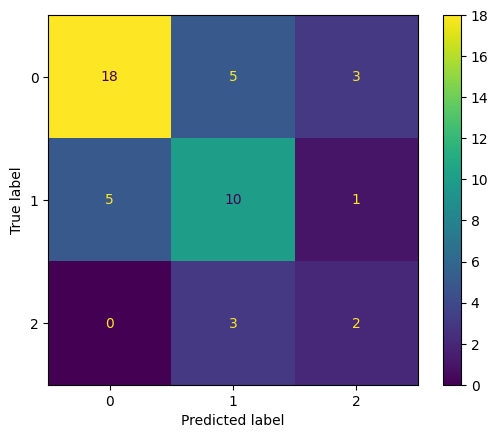

```python
X = classification_df.drop(columns=["Province", "Year", "energy_generated", "energy_capacity", "maximum_generation", 'Target'], axis = 1)
y = classification_df["Target"]
X_train, X_test, y_train, y_test = train_test_split(X, y, test_size=0.2, random_state = 9)

## Cross Validation
param_dist_dt = {'max_depth': randint(2,50)
}

# Create a random forest classifier
dt = DecisionTreeClassifier(random_state = 9)

# Use random search to find the best hyperparameters
rand_search_dt = RandomizedSearchCV(dt,
                                 param_distributions = param_dist_dt,
                                 cv=10,
                                 random_state=9)

# Fit the random search object to the data
rand_search_dt.fit(X_train, y_train)

# Print the best parameters and corresponding mean cross-validated score
print("Best Parameters: ", rand_search_dt.best_params_)
print("Best Cross-Validated Score: {:.2f}".format(rand_search_dt.best_score_))

# Evaluate the model on the test set with the best parameters
best_dt_classifier = rand_search_dt.best_estimator_
dt_predictions = best_dt_classifier.predict(X_test)
dt_test_accuracy = accuracy_score(y_test, best_dt_classifier.predict(X_test))
print("Test Set Accuracy with Best Parameters: {:.2f}".format(dt_test_accuracy))

cm_dt = confusion_matrix(y_test, dt_predictions)
ConfusionMatrixDisplay(confusion_matrix=cm_dt).plot()
```

Random Forest

Of the models we ran, our random forest model was the classification model that had the highest accuracy! And this makes sense, because the ensemble method is the average of many decision trees, so it stands to reason that the random forest will perform better than the decision tree. When we did the k-fold cross validation for decision trees, we thought to hypertune the max_depth and n_estimator parameters. For decision trees, max_depth is usually hypertuned to minimize overfitting the training data. But when we thought about this in regards to random forests, random forest already combat overfitting by averaging over many decision trees and randomizing which features are included in each tree. Because of this, we decided to not specify max_depth for random forests.

As for the n_estimators parameter, we decided to use sklearn's RandomizedSearchCV. We used RandomizedSearchCV instead of GridSearchCV because the former allows us to pass in a distribution of values rather than specific values. Since there are a large range of possible n_estimator values, using this cross validation strategy instead of the other ones was beneifical for us. Like the other classification models above, we decided to use 10 fold cross validation.

```
Best Parameters:  {'max_features': 4, 'n_estimators': 149}
Best Cross-Validated Score: 0.64
Test Set Accuracy with Best Parameters: 0.70
```

```
<sklearn.metrics._plot.confusion_matrix.ConfusionMatrixDisplay at 0x7f378c3be450>
```

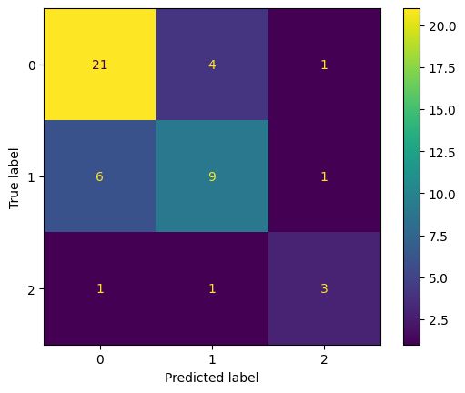

```python
## Cross Validation
param_dist_rf = {'n_estimators': randint(100,150),
                 'max_features': randint(2, 8)
}

# Create a random forest classifier
rf = RandomForestClassifier(random_state=9)

# Use random search to find the best hyperparameters
rand_search_rf = RandomizedSearchCV(rf,
                                 param_distributions = param_dist_rf,
                                 cv=10,
                                 random_state=9,
                                 scoring='accuracy')

# Fit the random search object to the data
rand_search_rf.fit(X_train, y_train)

# Print the best parameters and corresponding mean cross-validated score
print("Best Parameters: ", rand_search_rf.best_params_)
print("Best Cross-Validated Score: {:.2f}".format(rand_search_rf.best_score_))

# Evaluate the model on the test set with the best parameters
best_rf_classifier = rand_search_rf.best_estimator_
rf_test_accuracy = best_rf_classifier.score(X_test, y_test)
rf_y_pred = best_rf_classifier.predict(X_test)
print("Test Set Accuracy with Best Parameters: {:.2f}".format(rf_test_accuracy))

## show confusion matrix
cm_rf = confusion_matrix(y_test, rf_y_pred)
ConfusionMatrixDisplay(confusion_matrix=cm_rf).plot()
```

### Findings and 2024 Predictions

Our best model was random forest classification, with an accuracy of 0.70!! Now, we will use our random forest classifier, take the 2021 features, and use it to predict the 2024 classification. We will just put the code to make the series here, and will append it to our final predictions dataframe in the next section.

```python
clf_find_2024 = combined_df[combined_df['Year'] == 2021].reset_index().drop(['Province', 'energy_capacity', 'index', 'Year','energy_generated'], axis=1)
clf_2024_pred = best_rf_classifier.predict(clf_find_2024)

clf_find_2024['2024 Classification Prediction'] = clf_2024_pred
clf_find_2024
```

|  | prop_homeowners | prop_working | prop_school_absentees | prop_toilet_access | gdp | population | land_area | 2024 Classification Prediction |
| --- | --- | --- | --- | --- | --- | --- | --- | --- |
| 0 | 80.51 | 86.55 | 1.03 | 80.38 | 184976.30 | 5333.7 | 57956.00 | 1 |
| 1 | 67.57 | 88.61 | 1.44 | 88.91 | 859870.95 | 14936.2 | 72981.23 | 1 |
| 2 | 68.34 | 87.96 | 0.90 | 79.04 | 252749.65 | 5580.2 | 42012.89 | 1 |
| 3 | 72.52 | 91.23 | 0.71 | 92.30 | 843211.15 | 6493.6 | 87023.66 | 0 |
| 4 | 84.21 | 90.50 | 2.17 | 87.90 | 233725.46 | 2118.2 | 8201.72 | 0 |
| 5 | 81.32 | 90.56 | 0.81 | 82.81 | 491566.45 | 3585.1 | 50058.16 | 1 |
| 6 | 84.32 | 92.19 | 2.07 | 88.62 | 79576.33 | 8550.9 | 91592.43 | 1 |
| 7 | 89.40 | 91.69 | 1.66 | 91.92 | 371903.17 | 1473.2 | 16424.06 | 0 |
| 8 | 83.14 | 88.33 | 2.33 | 92.46 | 85942.70 | 2032.9 | 19919.33 | 1 |
| 9 | 66.83 | 88.71 | 1.29 | 94.55 | 275636.33 | 9081.8 | 34623.80 | 1 |
| 10 | 48.48 | 82.26 | 0.61 | 86.46 | 2914581.08 | 10609.7 | 664.01 | 1 |
| 11 | 79.63 | 86.56 | 1.80 | 86.16 | 2209822.38 | 48782.4 | 35377.76 | 1 |
| 12 | 89.92 | 87.51 | 4.01 | 88.66 | 1420799.91 | 12061.5 | 9662.92 | 2 |
| 13 | 76.53 | 82.11 | 3.11 | 83.80 | 149369.17 | 36742.5 | 32800.69 | 1 |
| 14 | 88.80 | 88.45 | 4.32 | 83.80 | 2454498.80 | 3712.9 | 3133.15 | 0 |
| 15 | 82.82 | 85.98 | 2.00 | 88.04 | 665921.92 | 40878.8 | 47799.75 | 2 |
| 16 | 73.92 | 88.91 | 4.21 | 85.95 | 219800.03 | 5470.8 | 5780.06 | 1 |
| 17 | 87.36 | 86.83 | 6.56 | 73.32 | 140153.32 | 2702.2 | 18572.32 | 0 |
| 18 | 85.22 | 89.92 | 4.20 | 79.20 | 110885.75 | 4122.6 | 48718.10 | 0 |
| 19 | 88.21 | 89.39 | 5.45 | 84.50 | 231321.16 | 3808.2 | 147307.00 | 1 |
| 20 | 77.04 | 91.52 | 1.11 | 84.60 | 170001.21 | 713.6 | 153564.50 | 1 |
| 21 | 79.83 | 87.99 | 1.54 | 87.24 | 192576.58 | 2638.6 | 38744.23 | 1 |
| 22 | 70.76 | 86.89 | 1.56 | 93.53 | 695158.33 | 1181.0 | 129066.64 | 0 |
| 23 | 69.60 | 88.55 | 1.99 | 92.44 | 110668.94 | 3021.9 | 75467.70 | 0 |
| 24 | 77.37 | 85.62 | 0.46 | 81.86 | 142600.02 | 9139.5 | 13851.64 | 1 |
| 25 | 84.46 | 90.76 | 2.73 | 76.90 | 246987.36 | 1436.8 | 11257.07 | 0 |
| 26 | 84.75 | 83.76 | 4.72 | 88.62 | 545230.03 | 2659.2 | 61841.29 | 1 |
| 27 | 86.33 | 88.71 | 3.64 | 85.64 | 139057.83 | 4362.7 | 46717.48 | 0 |
| 28 | 81.16 | 90.74 | 2.66 | 67.43 | 43896.37 | 5390.0 | 16787.18 | 0 |
| 29 | 89.72 | 91.21 | 5.34 | 77.96 | 50341.23 | 5387.7 | 38067.70 | 0 |
| 30 | 75.13 | 86.18 | 2.27 | 72.87 | 48564.22 | 1862.6 | 46914.03 | 0 |
| 31 | 83.40 | 89.85 | 1.08 | 69.73 | 52359.85 | 1299.2 | 31982.50 | 0 |
| 32 | 76.03 | 91.64 | 3.55 | 75.48 | 85072.86 | 1156.8 | 319036.05 | 0 |
| 33 | 83.20 | 94.32 | 25.55 | 63.34 | 235343.25 | 4355.5 | 99671.63 | 1 |
| 34 | 81.08 | 87.72 | 3.01 | 85.51 | 16970789.20 | 272682.5 | 1913578.68 | 1 |

# Interpretation and Conclusions

## 2024 Predictions Table

```python
predictions_tbl = pd.read_csv('/work/pred_2024.csv').drop(['[Ridge Regression] Effective generation? (Multiclass)',
                                             '[RF Classifcation] Effective  (>0.4 ratio) Generation? (Multiclass)',
                                             'Reg & Classif Match?'], axis=1)
predictions_tbl['2024 Classification Prediction'] = clf_2024_pred
predictions_tbl['2024 Efficiency Class Based on Regression'] = predictions_tbl['Ratio Generation:Capacity'].apply(make_target)
predictions_tbl
```

|  | Province | 2024 Energy Generation (GWh) | 2024 Maximum Generation Capacity (GWh) | Ratio Generation:Capacity | 2024 Classification Prediction | 2024 Efficiency Class Based on Regression |
| --- | --- | --- | --- | --- | --- | --- |
| 0 | ACEH | 5418.184195 | 9934.567809 | 0.545387 | 1 | 1 |
| 1 | SUMATERA UTARA | 15442.784830 | 32265.272320 | 0.478619 | 1 | 1 |
| 2 | SUMATERA BARAT | 3716.216443 | 9062.870019 | 0.410049 | 1 | 1 |
| 3 | RIAU | 9846.534150 | 21913.593590 | 0.449335 | 0 | 1 |
| 4 | JAMBI | 4652.658456 | 7224.840226 | 0.643981 | 0 | 2 |
| 5 | SUMATERA SELATAN | 6882.536526 | 13718.806700 | 0.501686 | 1 | 1 |
| 6 | BENGKULU | 7468.150508 | 12694.705030 | 0.588289 | 1 | 1 |
| 7 | LAMPUNG | 6376.697912 | 10038.375150 | 0.635232 | 0 | 2 |
| 8 | KEP. BANGKA BELITUNG | 3067.004610 | 3766.975184 | 0.814182 | 1 | 2 |
| 9 | KEP. RIAU | 6428.649232 | 13130.731290 | 0.489588 | 1 | 1 |
| 10 | DKI JAKARTA | 25861.107170 | 61591.475220 | 0.419881 | 1 | 1 |
| 11 | JAWA BARAT | 55248.019370 | 105142.486800 | 0.525459 | 1 | 1 |
| 12 | JAWA TENGAH | 23194.661970 | 43797.561410 | 0.529588 | 2 | 1 |
| 13 | DI YOGYAKARTA | 28364.384910 | 49252.568050 | 0.575897 | 1 | 1 |
| 14 | JAWA TIMUR | 25178.549600 | 52450.265320 | 0.480046 | 0 | 1 |
| 15 | BANTEN | 37029.315710 | 65928.499400 | 0.561659 | 2 | 1 |
| 16 | BALI | 4835.185981 | 8975.911373 | 0.538685 | 1 | 1 |
| 17 | NUSA TENGGARA BARAT | 4629.148779 | 6926.173984 | 0.668356 | 0 | 2 |
| 18 | NUSA TENGGARA TIMUR | 4831.742279 | 7827.048573 | 0.617313 | 0 | 2 |
| 19 | KALIMANTAN BARAT | 5261.469210 | 9837.255970 | 0.534851 | 1 | 1 |
| 20 | KALIMANTAN TENGAH | 109.529077 | 2672.989995 | 0.040976 | 1 | 0 |
| 21 | KALIMANTAN SELATAN | 3507.565844 | 6131.312787 | 0.572074 | 1 | 1 |
| 22 | KALIMANTAN TIMUR | 3802.563555 | 11370.482680 | 0.334424 | 0 | 1 |
| 23 | KALIMANTAN UTARA | 605.474448 | 2570.395062 | 0.235557 | 0 | 0 |
| 24 | SULAWESI UTARA | 7761.745718 | 13484.187790 | 0.575618 | 1 | 1 |
| 25 | SULAWESI TENGAH | 4153.346366 | 7045.062236 | 0.589540 | 0 | 1 |
| 26 | SULAWESI SELATAN | 7184.950593 | 13371.762290 | 0.537323 | 1 | 1 |
| 27 | SULAWESI TENGGARA | 5585.506761 | 8662.637537 | 0.644781 | 0 | 2 |
| 28 | GORONTALO | 4641.068513 | 8064.264142 | 0.575510 | 0 | 1 |
| 29 | SULAWESI BARAT | 6294.380979 | 9316.367674 | 0.675626 | 0 | 2 |
| 30 | MALUKU | 507.706011 | 1807.034600 | 0.280961 | 0 | 0 |
| 31 | MALUKU UTARA | 2013.843908 | 3329.099125 | 0.604922 | 0 | 2 |
| 32 | PAPUA BARAT | -2262.656444 | 1318.813373 | -1.715676 | 0 | 0 |
| 33 | PAPUA | 4165.998716 | 8729.533181 | 0.477230 | 1 | 1 |
| 34 | INDONESIA | 329397.072300 | 677903.714000 | 0.485905 | 1 | 1 |

```python
## interesting summary statistics of final 2024 predictions
print('Ratio Mean: ' + str(predictions_tbl['Ratio Generation:Capacity'].mean()))
print('Regression 2024 Efficiency Predictions: ' + '\n' + str(predictions_tbl['2024 Efficiency Class Based on Regression'].value_counts()))
print('Classification 2024 Efficiency Predictions: ' + '\n' + str(predictions_tbl['2024 Classification Prediction'].value_counts()))
```

```
Ratio Mean: 0.45493870737828573
Regression 2024 Efficiency Predictions:
1    23
2     8
0     4
Name: 2024 Efficiency Class Based on Regression, dtype: int64
Classification 2024 Efficiency Predictions:
1    18
0    15
2     2
Name: 2024 Classification Prediction, dtype: int64
```

## Resource Allocation

Although Indonesia has the most developed economy in Southeast Asia, they still have transmission and distribution issues, especially in rural areas, which are further exacerbated by natural events such as earthquakes. Knowing how much energy will be generated in a province can help the government subsidized electricity provider “PLN” plan ahead.

Forecasts of future energy generation could be looked at along with population trends to determine if each province will be generate enough in a given year to keep up with the needs of its population? If so, look at province’s infrastructure and try to emulate nationally. If not, allocate funds to improve infrastructure and increase energy importation.

Indonesia has not lived up to its full potential in terms of renewable energy development. Using predictions of future gaps between energy capacity and generation, Indonesian lobbyists and activists could know which provinces to pour more resources and effort into in terms of campaigning for the government to develop more solar, wind, geothermal, and hydropower energy infrastructure. A grid that has more capacity than generation might need to see other sources of energy for that capacity to be met.

## Limitations

[figure not shown]

Created in Deepnote